# Ghana Micronutrient Deficiency & GEE Predictors

Admin1 and Admin2 descriptive analysis with SuperLearner prediction

Author

MN Prediction Pipeline

Published

March 18, 2026

```r
library(here)
library(dplyr)
library(tidyr)
library(ggplot2)
library(sf)
library(viridis)
library(scales)
library(knitr)
library(patchwork)
library(geodata)
library(terra)
library(exactextractr)
library(readr)
library(SuperLearner)
```

## Overview

This report describes the Admin1- and Admin2-level analytic datasets for Ghana, built by aggregating individual-level micronutrient survey data (2017 Ghana Micronutrient Survey) and merging with **all** Google Earth Engine (GEE) raster predictors in the `data/Ghana_GEE rasters/` folder, averaged over each administrative unit. Multi-layer .tif files are handled by extracting each layer as a separate variable.

**Survey design:** The Ghana Micronutrient Survey 2017 uses a **stratified, cluster-sampled design** with survey weights. Prevalence estimates are computed using the `srvyr` package with:

- **PSU (cluster):** `gw_cnum` (90 enumeration areas)
- **Strata:** `gw_Strata`
- **Weights:** `gw_sWeight`
- **Lonely PSU handling:** `options(survey.lonely.psu = "adjust")`

This ensures correct variance estimation and confidence intervals that account for the complex survey design, rather than treating observations as independent.

**Outcome:** Vitamin A deficiency (VAD) prevalence in children, defined as retinol-binding protein (RBP, Brinda-adjusted) < 0.70 µmol/L.

**GEE predictors:** All .tif rasters from the Ghana GEE folder, including NDVI, TRMM precipitation, population density, land surface temperature, FLDAS climate variables, soil properties (multiple depth layers), crop classification, human modification index, settlement type, nighttime lights, grassland cover, and net primary productivity (WAPOR).

## Build the Datasets

```r
a1_path    <- here::here("data", "Ghana_admin1_analytic.rds")
a1_sf_path <- here::here("data", "Ghana_admin1_analytic_sf.rds")
a2_path    <- here::here("data", "Ghana_admin2_analytic.rds")
a2_sf_path <- here::here("data", "Ghana_admin2_analytic_sf.rds")

if (all(file.exists(a1_path, a1_sf_path, a2_path, a2_sf_path))) {
  admin1_df <- readRDS(a1_path)
  admin1_sf <- readRDS(a1_sf_path)
  admin2_df <- readRDS(a2_path)
  admin2_sf <- readRDS(a2_sf_path)
  cat("Loaded saved datasets.\n")
} else {
  cat("Building datasets from scratch...\n")
  source(here::here("scripts", "07_ghana_admin2_gee_dataset.R"))
  admin1_df <- readRDS(a1_path)
  admin1_sf <- readRDS(a1_sf_path)
  admin2_df <- readRDS(a2_path)
  admin2_sf <- readRDS(a2_sf_path)
}
```

```
Loaded saved datasets.
```

```r
# Identify GEE predictor columns (all starting with gee_)
gee_cols <- grep("^gee_", names(admin1_df), value = TRUE)
cat(sprintf("GEE predictor columns: %d\n", length(gee_cols)))
```

```
GEE predictor columns: 345
```

```r
# Full GADM polygons for mapping (grey = no data)
poly_a1 <- geodata::gadm(country = "GHA", level = 1, path = tempdir())
poly_a1 <- sf::st_as_sf(poly_a1) %>%
  select(NAME_1) %>% rename(Admin1_gadm = NAME_1) %>%
  sf::st_transform(crs = 4326)

poly_a2 <- geodata::gadm(country = "GHA", level = 2, path = tempdir())
poly_a2 <- sf::st_as_sf(poly_a2) %>%
  select(NAME_1, NAME_2) %>%
  rename(Admin1_gadm = NAME_1, Admin2_gadm = NAME_2) %>%
  sf::st_transform(crs = 4326)

# Map join
map_a1 <- poly_a1 %>%
  left_join(admin1_df %>% select(-Admin1_gadm), by = c("Admin1_gadm" = "Admin1"))

gee_cols_a2 <- grep("^gee_", names(admin2_df), value = TRUE)
map_a2 <- poly_a2 %>%
  left_join(
    admin2_df %>% select(Admin2_gadm, svy_prev_vad, n_children,
                         all_of(gee_cols_a2)),
    by = "Admin2_gadm"
  )
```

## Survey Data Summary

### National

```r
data.frame(
  Metric = c("Total children (complete cases)", "National weighted VAD prevalence",
             "GEE predictor variables"),
  Value  = c(sprintf("%d", sum(admin1_df$n_children)),
             sprintf("%.1f%%", weighted.mean(admin1_df$svy_prev_vad,
                                              admin1_df$n_children) * 100),
             as.character(length(gee_cols)))
) %>% kable()
```

| Metric | Value |
| --- | --- |
| Total children (complete cases) | 1165 |
| National weighted VAD prevalence | 28.9% |
| GEE predictor variables | 345 |

### Admin1 Regions (survey-weighted)

```r
admin1_df %>%
  arrange(desc(svy_prev_vad)) %>%
  mutate(
    `Weighted prev` = sprintf("%.1f%% [%.1f, %.1f]",
      svy_prev_vad * 100, svy_prev_vad_low * 100, svy_prev_vad_upp * 100),
    `Raw prev` = sprintf("%.1f%%", raw_prev_vad * 100),
    `Mean RBP` = round(mean_rbp, 3)
  ) %>%
  select(Admin1, n_children, `Weighted prev`, `Raw prev`, `Mean RBP`) %>%
  kable(caption = "Admin1 VAD prevalence (survey-weighted with 95% CI)")
```

Admin1 VAD prevalence (survey-weighted with 95% CI)

| Admin1 | n_children | Weighted prev | Raw prev | Mean RBP |
| --- | --- | --- | --- | --- |
| Northern | 143 | 42.7% [31.1, 54.3] | 42.7% | 0.886 |
| Upper East | 81 | 37.0% [28.7, 45.4] | 37.0% | 0.904 |
| Savannah | 63 | 34.9% [23.5, 46.4] | 34.9% | 0.943 |
| Ahafo | 62 | 33.9% [28.9, 38.8] | 33.9% | 1.044 |
| Central | 72 | 33.3% [25.0, 41.7] | 33.3% | 1.000 |
| North East | 45 | 31.1% [20.9, 41.3] | 31.1% | 0.899 |
| Western | 64 | 29.7% [24.3, 35.1] | 29.7% | 1.103 |
| Eastern | 110 | 26.6% [16.8, 36.4] | 26.4% | 1.048 |
| Volta | 40 | 25.0% [6.7, 43.3] | 25.0% | 1.193 |
| Upper West | 70 | 24.3% [13.9, 34.7] | 24.3% | 1.013 |
| Greater Accra | 99 | 24.2% [13.8, 34.7] | 24.2% | 1.060 |
| Bono East | 46 | 23.9% [10.7, 37.2] | 23.9% | 1.048 |
| Ashanti | 204 | 21.6% [14.0, 29.2] | 21.6% | 1.043 |
| Western North | 19 | 21.1% [21.1, 21.1] | 21.1% | 1.075 |
| Oti | 14 | 14.3% [14.3, 14.3] | 14.3% | 1.293 |
| Bono | 33 | 12.1% [6.1, 18.2] | 12.1% | 1.249 |

### Admin2 Districts (survey-weighted, top 20)

```r
admin2_df %>%
  arrange(desc(svy_prev_vad)) %>%
  head(20) %>%
  mutate(
    `Weighted prev` = sprintf("%.1f%% [%.1f, %.1f]",
      svy_prev_vad * 100, svy_prev_vad_low * 100, svy_prev_vad_upp * 100),
    `Raw prev` = sprintf("%.1f%%", raw_prev_vad * 100)
  ) %>%
  select(Admin1, Admin2, n_children, `Weighted prev`, `Raw prev`) %>%
  kable(caption = "Top 20 Admin2 districts by VAD prevalence (survey-weighted)")
```

Top 20 Admin2 districts by VAD prevalence (survey-weighted)

| Admin1 | Admin2 | n_children | Weighted prev | Raw prev |
| --- | --- | --- | --- | --- |
| Northern | Tolon | 32 | 62.5% [62.5, 62.5] | 62.5% |
| Volta | Akatsi South | 8 | 62.5% [62.5, 62.5] | 62.5% |
| Savannah | North East Gonja | 11 | 54.5% [54.5, 54.5] | 54.5% |
| Central | Mfantseman | 6 | 50.0% [50.0, 50.0] | 50.0% |
| Central | Twifo-Hemang-Lower Denkyira | 6 | 50.0% [50.0, 50.0] | 50.0% |
| Eastern | Denkyembour | 14 | 50.0% [50.0, 50.0] | 50.0% |
| Northern | Gushegu | 10 | 50.0% [50.0, 50.0] | 50.0% |
| Savannah | Bole | 4 | 50.0% [50.0, 50.0] | 50.0% |
| Northern | Tamale | 25 | 48.0% [48.0, 48.0] | 48.0% |
| Ashanti | Atwima-Mponua | 32 | 43.8% [39.3, 48.2] | 43.8% |
| Upper East | Binduri | 30 | 43.3% [27.8, 58.9] | 43.3% |
| Northern | Savelugu | 17 | 41.2% [41.2, 41.2] | 41.2% |
| North East | West Mamprusi | 23 | 39.1% [39.1, 39.1] | 39.1% |
| Savannah | Sawla-Tuna-Kalba | 18 | 38.9% [38.9, 38.9] | 38.9% |
| Upper East | Talensi | 13 | 38.5% [38.5, 38.5] | 38.5% |
| Central | Agona West | 21 | 38.1% [38.1, 38.1] | 38.1% |
| Ashanti | Bekwai | 8 | 37.5% [37.5, 37.5] | 37.5% |
| Central | Twifo-Atti-Morkwa | 8 | 37.5% [37.5, 37.5] | 37.5% |
| Western | Jomoro | 8 | 37.5% [37.5, 37.5] | 37.5% |
| Bono East | Kintampo North | 19 | 36.8% [36.8, 36.8] | 36.8% |

### Weighted vs Unweighted Prevalence

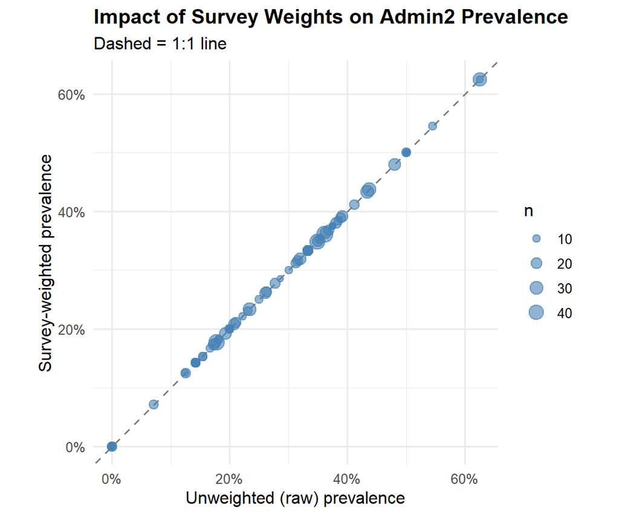

```r
ggplot(admin2_df, aes(x = raw_prev_vad, y = svy_prev_vad)) +
  geom_abline(slope = 1, intercept = 0, linetype = "dashed", colour = "grey50") +
  geom_point(aes(size = n_children), alpha = 0.6, colour = "steelblue") +
  scale_x_continuous(labels = percent_format(1)) +
  scale_y_continuous(labels = percent_format(1)) +
  scale_size_area(name = "n", max_size = 5) +
  labs(x = "Unweighted (raw) prevalence",
       y = "Survey-weighted prevalence",
       title = "Impact of Survey Weights on Admin2 Prevalence",
       subtitle = "Dashed = 1:1 line") +
  coord_fixed() +
  theme_minimal(base_size = 12) +
  theme(plot.title = element_text(face = "bold"))
```

## Maps: VAD Prevalence

### Admin1 Prevalence Map

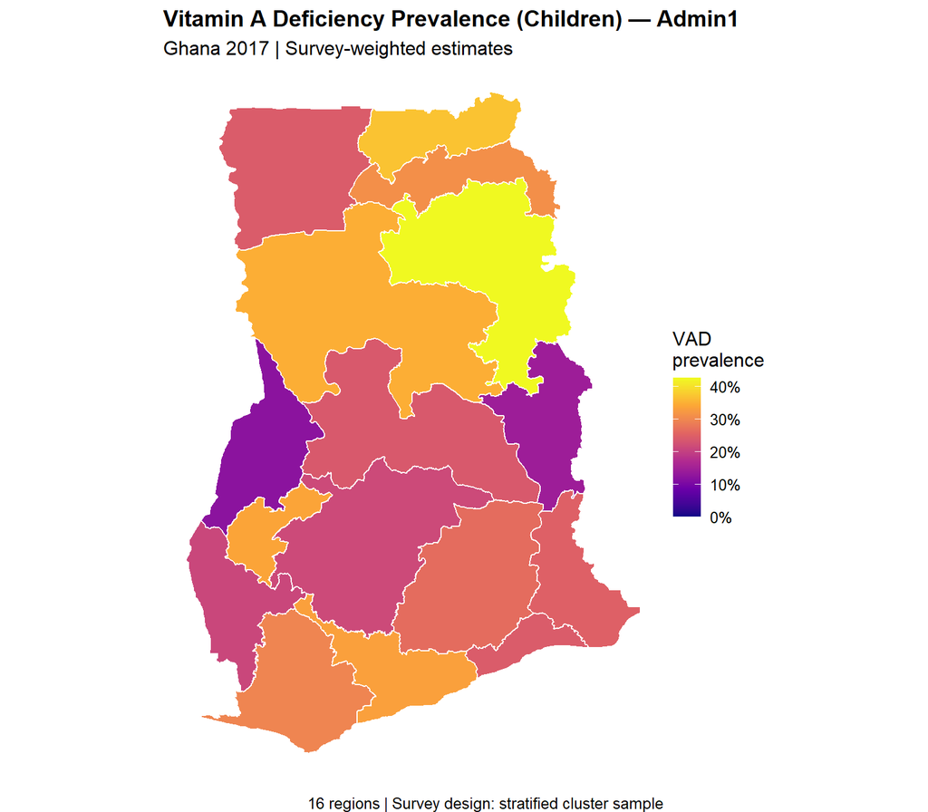

```r
ggplot(map_a1) +
  geom_sf(aes(fill = svy_prev_vad), colour = "white", linewidth = 0.4) +
  scale_fill_viridis_c(
    name   = "VAD\nprevalence",
    labels = percent_format(accuracy = 1),
    limits = c(0, NA),
    na.value = "grey85",
    option = "plasma"
  ) +
  labs(
    title    = "Vitamin A Deficiency Prevalence (Children) — Admin1",
    subtitle = "Ghana 2017 | Survey-weighted estimates",
    caption  = sprintf("%d regions | Survey design: stratified cluster sample",
                       nrow(admin1_df))
  ) +
  theme_void(base_size = 12) +
  theme(plot.title = element_text(face = "bold", size = 14),
        legend.position = "right")
```

### Admin1 Forest Plot with 95% CIs

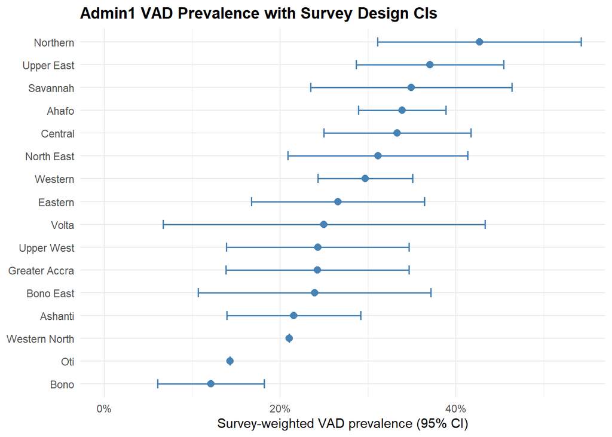

```r
forest_a1 <- admin1_df %>%
  arrange(svy_prev_vad) %>%
  mutate(Admin1 = factor(Admin1, levels = Admin1))

ggplot(forest_a1, aes(x = svy_prev_vad, y = Admin1,
                       xmin = svy_prev_vad_low, xmax = svy_prev_vad_upp)) +
  geom_errorbarh(colour = "steelblue", height = 0.4, linewidth = 0.6) +
  geom_point(colour = "steelblue", size = 2.5) +
  scale_x_continuous(labels = percent_format(1), limits = c(0, NA)) +
  labs(x = "Survey-weighted VAD prevalence (95% CI)",
       y = NULL,
       title = "Admin1 VAD Prevalence with Survey Design CIs") +
  theme_minimal(base_size = 11) +
  theme(plot.title = element_text(face = "bold"))
```

### Admin2 Prevalence Map

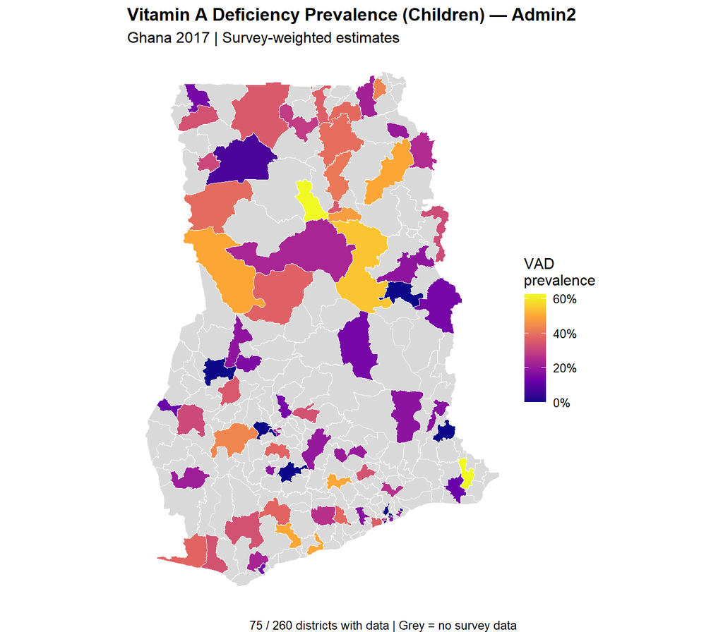

```r
ggplot(map_a2) +
  geom_sf(aes(fill = svy_prev_vad), colour = "white", linewidth = 0.2) +
  scale_fill_viridis_c(
    name   = "VAD\nprevalence",
    labels = percent_format(accuracy = 1),
    limits = c(0, NA),
    na.value = "grey85",
    option = "plasma"
  ) +
  labs(
    title    = "Vitamin A Deficiency Prevalence (Children) — Admin2",
    subtitle = "Ghana 2017 | Survey-weighted estimates",
    caption  = sprintf("%d / %d districts with data | Grey = no survey data",
                       sum(!is.na(map_a2$svy_prev_vad)), nrow(map_a2))
  ) +
  theme_void(base_size = 12) +
  theme(plot.title = element_text(face = "bold", size = 14),
        legend.position = "right")
```

## GEE Raster Predictors: Overview

```r
# Categorise GEE variables by source
gee_categories <- data.frame(variable = gee_cols) %>%
  mutate(
    source = case_when(
      grepl("ndvi", variable)     ~ "NDVI (vegetation)",
      grepl("trmm", variable)     ~ "TRMM (precipitation)",
      grepl("popdens", variable)  ~ "Population density",
      grepl("soil", variable)     ~ "Soil properties",
      grepl("fldas", variable)    ~ "FLDAS (climate/land surface)",
      grepl("wapor", variable)    ~ "WAPOR (net primary production)",
      grepl("lst", variable)      ~ "LST (land surface temperature)",
      grepl("gpw_dem", variable)  ~ "GPW (demographics)",
      grepl("gpw_grass", variable) ~ "GPW (grasslands)",
      grepl("esa", variable)      ~ "ESA (crop classification)",
      grepl("ghsl", variable)     ~ "GHSL (settlement type)",
      grepl("ccnl", variable)     ~ "CCNL (nighttime lights)",
      grepl("ghm|human_mod", variable) ~ "Human modification",
      TRUE                        ~ "Other"
    )
  )

gee_categories %>%
  count(source, name = "n_variables") %>%
  arrange(desc(n_variables)) %>%
  kable(caption = sprintf("GEE predictor categories (%d total variables)", length(gee_cols)))
```

GEE predictor categories (345 total variables)

| source | n_variables |
| --- | --- |
| Soil properties | 104 |
| GPW (demographics) | 77 |
| WAPOR (net primary production) | 72 |
| FLDAS (climate/land surface) | 40 |
| Population density | 14 |
| NDVI (vegetation) | 13 |
| TRMM (precipitation) | 10 |
| ESA (crop classification) | 6 |
| LST (land surface temperature) | 4 |
| GPW (grasslands) | 2 |
| CCNL (nighttime lights) | 1 |
| GHSL (settlement type) | 1 |
| Other | 1 |

### Summary Statistics (selected predictors)

```r
# Pick a few representative single-layer variables for detailed stats
# Dynamically select one from each major category if available
representative <- c(
  grep("^gee_ndvi_2017$", gee_cols, value = TRUE),
  grep("^gee_trmm_2017$", gee_cols, value = TRUE),
  grep("^gee_popdens.*2017$", gee_cols, value = TRUE),
  grep("^gee_lst.*2015", gee_cols, value = TRUE),
  grep("^gee_ccnl", gee_cols, value = TRUE),
  grep("^gee_ghsl", gee_cols, value = TRUE),
  grep("^gee_global", gee_cols, value = TRUE)
)
# If none matched via those patterns, fall back to first few gee_cols
if (length(representative) == 0) representative <- head(gee_cols, 7)

admin1_df %>%
  select(any_of(representative)) %>%
  pivot_longer(everything(), names_to = "variable", values_to = "value") %>%
  group_by(variable) %>%
  summarise(
    n      = sum(!is.na(value)),
    mean   = round(mean(value, na.rm = TRUE), 3),
    sd     = round(sd(value, na.rm = TRUE), 3),
    min    = round(min(value, na.rm = TRUE), 3),
    median = round(median(value, na.rm = TRUE), 3),
    max    = round(max(value, na.rm = TRUE), 3),
    .groups = "drop"
  ) %>%
  kable(caption = "Summary statistics for selected GEE predictors (Admin1 means)")
```

Summary statistics for selected GEE predictors (Admin1 means)

| variable | n | mean | sd | min | median | max |
| --- | --- | --- | --- | --- | --- | --- |
| gee_ccnl_2013 | 16 | 1.308 | 3.177 | 0.025 | 0.358 | 13.060 |
| gee_ghsl_smod_2015 | 16 | 11.781 | 1.325 | 11.044 | 11.415 | 16.587 |
| gee_globalhumanmodification_2016 | 16 | 0.458 | 0.131 | 0.160 | 0.482 | 0.658 |
| gee_lst_night_2015_annual_mean__filledproportion | 16 | 18.835 | 8.186 | 5.626 | 18.403 | 29.780 |
| gee_lst_night_2015_annual_mean__mean | 16 | 21.422 | 0.634 | 20.337 | 21.500 | 22.322 |
| gee_popdensity_ghana_2017 | 16 | 179.977 | 294.056 | 16.811 | 91.977 | 1252.691 |

### Missingness

```r
na_counts <- admin1_df %>%
  select(all_of(gee_cols)) %>%
  summarise(across(everything(), ~sum(is.na(.)))) %>%
  pivot_longer(everything(), names_to = "variable", values_to = "n_missing") %>%
  filter(n_missing > 0)

if (nrow(na_counts) > 0) {
  na_counts %>%
    arrange(desc(n_missing)) %>%
    head(20) %>%
    kable(caption = "GEE variables with missing values at Admin1 (top 20)")
} else {
  cat("No missing values across any GEE predictor at Admin1 level.\n")
}
```

GEE variables with missing values at Admin1 (top 20)

| variable | n_missing |
| --- | --- |
| gee_ndvi_ghana_2022 | 16 |

## Correlation with VAD Prevalence

```r
# Compute correlation of each GEE predictor with VAD prevalence (Admin1)
cor_with_vad <- sapply(gee_cols, function(v) {
  x <- admin1_df[[v]]
  if (all(is.na(x)) || sd(x, na.rm = TRUE) == 0) return(NA_real_)
  cor(x, admin1_df$svy_prev_vad, use = "complete.obs")
})

cor_df <- data.frame(
  variable = names(cor_with_vad),
  correlation = cor_with_vad,
  abs_cor = abs(cor_with_vad)
) %>%
  filter(!is.na(correlation)) %>%
  arrange(desc(abs_cor))

# Show top 20
cor_df %>%
  head(20) %>%
  mutate(correlation = round(correlation, 3)) %>%
  kable(caption = "Top 20 GEE predictors most correlated with VAD prevalence (Admin1)")
```

Top 20 GEE predictors most correlated with VAD prevalence (Admin1)

|  | variable | correlation | abs_cor |
| --- | --- | --- | --- |
| gee_soilsulfur_ghana_2016__stdev_0_20 | gee_soilsulfur_ghana_2016__stdev_0_20 | -0.605 | 0.6049180 |
| gee_soilsulfur_ghana_2017__stdev_0_20 | gee_soilsulfur_ghana_2017__stdev_0_20 | -0.605 | 0.6049180 |
| gee_esa_worldcereal_2021__32121_tc_maize_main_activecropland_20210327_20211119_classif | gee_esa_worldcereal_2021__32121_tc_maize_main_activecropland_20210327_20211119_classif | 0.583 | 0.5827649 |
| gee_esa_worldcereal_2021__32121_tc_maize_second_activecropland_20200726_20210104_class | gee_esa_worldcereal_2021__32121_tc_maize_second_activecropland_20200726_20210104_class | 0.555 | 0.5552016 |
| gee_wapor_ghana_2016__l1_npp_1624_l1_npp_d | gee_wapor_ghana_2016__l1_npp_1624_l1_npp_d | 0.507 | 0.5068445 |
| gee_wapor_ghana_2016__l1_npp_1626_l1_npp_d | gee_wapor_ghana_2016__l1_npp_1626_l1_npp_d | 0.482 | 0.4817528 |
| gee_ndvi_ghana_2021 | gee_ndvi_ghana_2021 | -0.475 | 0.4752224 |
| gee_soilnitrogen_ghana_2016__stdev_0_20 | gee_soilnitrogen_ghana_2016__stdev_0_20 | -0.452 | 0.4519335 |
| gee_soilnitrogen_ghana_2017__stdev_0_20 | gee_soilnitrogen_ghana_2017__stdev_0_20 | -0.452 | 0.4519335 |
| gee_wapor_ghana_2016__l1_npp_1625_l1_npp_d | gee_wapor_ghana_2016__l1_npp_1625_l1_npp_d | 0.442 | 0.4421924 |
| gee_esa_worldcereal_2021__32121_tc_wintercereals_activecropland_20201115_20210607_clas | gee_esa_worldcereal_2021__32121_tc_wintercereals_activecropland_20201115_20210607_clas | 0.440 | 0.4400432 |
| gee_soilaluminium_ghana_2016__stdev_0_20 | gee_soilaluminium_ghana_2016__stdev_0_20 | 0.429 | 0.4288113 |
| gee_soilaluminium_ghana_2017__stdev_0_20 | gee_soilaluminium_ghana_2017__stdev_0_20 | 0.429 | 0.4288113 |
| gee_wapor_ghana_2016__l1_npp_1623_l1_npp_d | gee_wapor_ghana_2016__l1_npp_1623_l1_npp_d | 0.421 | 0.4207516 |
| gee_lst_night_2015_annual_mean__mean | gee_lst_night_2015_annual_mean__mean | 0.416 | 0.4161652 |
| gee_wapor_ghana_2016__l1_npp_1621_l1_npp_d | gee_wapor_ghana_2016__l1_npp_1621_l1_npp_d | 0.410 | 0.4100120 |
| gee_fldas_2017_annual_mean__qg_tavg | gee_fldas_2017_annual_mean__qg_tavg | -0.404 | 0.4040553 |
| gee_wapor_ghana_2017__l1_npp_1724_l1_npp_d | gee_wapor_ghana_2017__l1_npp_1724_l1_npp_d | 0.404 | 0.4040244 |
| gee_ndvi_ghana_2020 | gee_ndvi_ghana_2020 | -0.402 | 0.4021101 |
| gee_fldas_2016_annual_mean__soilmoi00_10cm_tavg | gee_fldas_2016_annual_mean__soilmoi00_10cm_tavg | -0.400 | 0.4000595 |

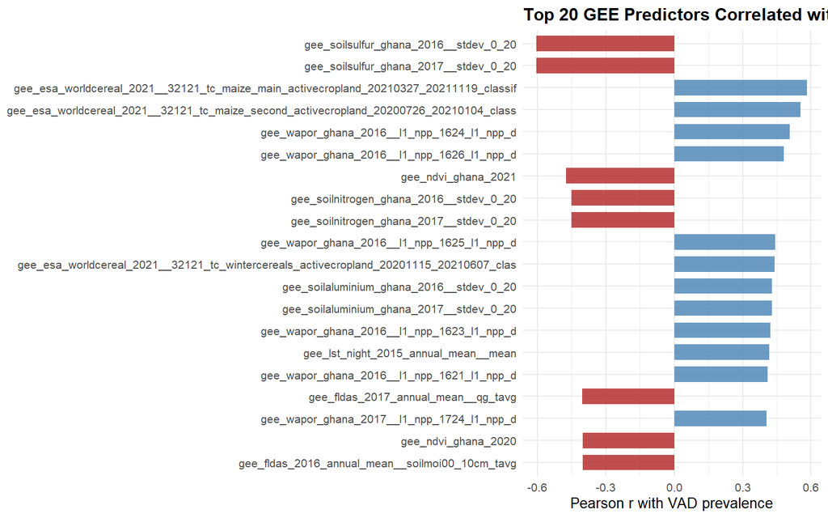

```r
top_n_cor <- min(20, nrow(cor_df))
cor_top <- cor_df %>% head(top_n_cor)

cor_top %>%
  mutate(variable = factor(variable, levels = rev(variable))) %>%
  ggplot(aes(x = variable, y = correlation,
             fill = ifelse(correlation > 0, "Positive", "Negative"))) +
  geom_col(alpha = 0.8, width = 0.7) +
  scale_fill_manual(values = c("Positive" = "steelblue", "Negative" = "firebrick"),
                    guide = "none") +
  coord_flip() +
  labs(x = NULL, y = "Pearson r with VAD prevalence",
       title = sprintf("Top %d GEE Predictors Correlated with VAD (Admin1)", top_n_cor)) +
  theme_minimal(base_size = 10) +
  theme(plot.title = element_text(face = "bold"))
```

## SuperLearner Analysis

We fit a SuperLearner ensemble on the Admin1-level dataset (n = 16) to predict survey-weighted VAD prevalence from all available GEE predictors. Variables with zero variance or all-NA values are removed. Because n is small, we use leave-one-out cross-validation (LOOCV).

**Learner library:**

- `SL.mean` — intercept-only baseline (grand mean)
- `SL.glmnet` — elastic net (handles p > n via regularisation)
- `SL.randomForest` — random forest (500 trees)

```r
# Prepare Admin1 analytic matrix with all GEE predictors
sl_data <- admin1_df %>%
  filter(!is.na(svy_prev_vad)) %>%
  as.data.frame()

Y <- sl_data$svy_prev_vad

# Select GEE columns, drop all-NA or zero-variance
X <- sl_data[, gee_cols, drop = FALSE]
keep <- sapply(X, function(col) {
  !all(is.na(col)) && sd(col, na.rm = TRUE) > 0
})
X <- X[, keep, drop = FALSE]

# Impute remaining NA with column median (required for SL)
for (j in seq_len(ncol(X))) {
  nas <- is.na(X[[j]])
  if (any(nas)) X[[j]][nas] <- median(X[[j]], na.rm = TRUE)
}

cat(sprintf("SuperLearner: n = %d, p = %d predictors, V = %d (LOOCV)\n",
            nrow(X), ncol(X), nrow(X)))
```

```
SuperLearner: n = 16, p = 336 predictors, V = 16 (LOOCV)
```

```r
set.seed(12345)

# Custom RF wrapper for high-dimensional, small-n setting:
# cap mtry = sqrt(p), increase nodesize = 5
SL.rf.small <- function(Y, X, newX, family, mtry = max(1, floor(sqrt(ncol(X)))),
                         nodesize = 5, ntree = 500, ...) {
  SuperLearner::SL.randomForest(
    Y = Y, X = X, newX = newX, family = family,
    mtry = mtry, nodesize = nodesize, ntree = ntree, ...
  )
}

sl_fit <- SuperLearner::SuperLearner(
  Y          = Y,
  X          = X,
  family     = gaussian(),
  SL.library = c("SL.mean", "SL.glmnet", "SL.rf.small"),
  cvControl  = list(V = nrow(X))   # LOOCV
)

cat("SuperLearner fit complete.\n")
```

```
SuperLearner fit complete.
```

### Metalearner Weights

```r
coef_df <- data.frame(
  Learner = sl_fit$libraryNames,
  Weight  = round(coef(sl_fit), 4)
)
kable(coef_df, caption = "SuperLearner metalearner (NNLS) weights")
```

SuperLearner metalearner (NNLS) weights

|  | Learner | Weight |
| --- | --- | --- |
| SL.mean_All | SL.mean_All | 0.7235 |
| SL.glmnet_All | SL.glmnet_All | 0.0000 |
| SL.rf.small_All | SL.rf.small_All | 0.2765 |

### Cross-Validated Performance

```r
cv_preds <- sl_fit$Z %*% coef(sl_fit)
cv_preds <- as.numeric(cv_preds)

r2_cv  <- 1 - sum((Y - cv_preds)^2) / sum((Y - mean(Y))^2)
mse_cv <- mean((Y - cv_preds)^2)
mae_cv <- mean(abs(Y - cv_preds))
cor_cv <- cor(Y, cv_preds)

perf_df <- data.frame(
  Metric = c("CV R-squared", "CV MSE", "CV MAE (pp)", "CV Pearson r",
             "Predictors used"),
  Value  = c(sprintf("%.3f", r2_cv),
             sprintf("%.6f", mse_cv),
             sprintf("%.1f", mae_cv * 100),
             sprintf("%.3f", cor_cv),
             as.character(ncol(X)))
)
kable(perf_df, caption = "LOOCV performance of SuperLearner ensemble (all GEE predictors)")
```

LOOCV performance of SuperLearner ensemble (all GEE predictors)

| Metric | Value |
| --- | --- |
| CV R-squared | -0.128 |
| CV MSE | 0.007022 |
| CV MAE (pp) | 6.9 |
| CV Pearson r | -0.506 |
| Predictors used | 336 |

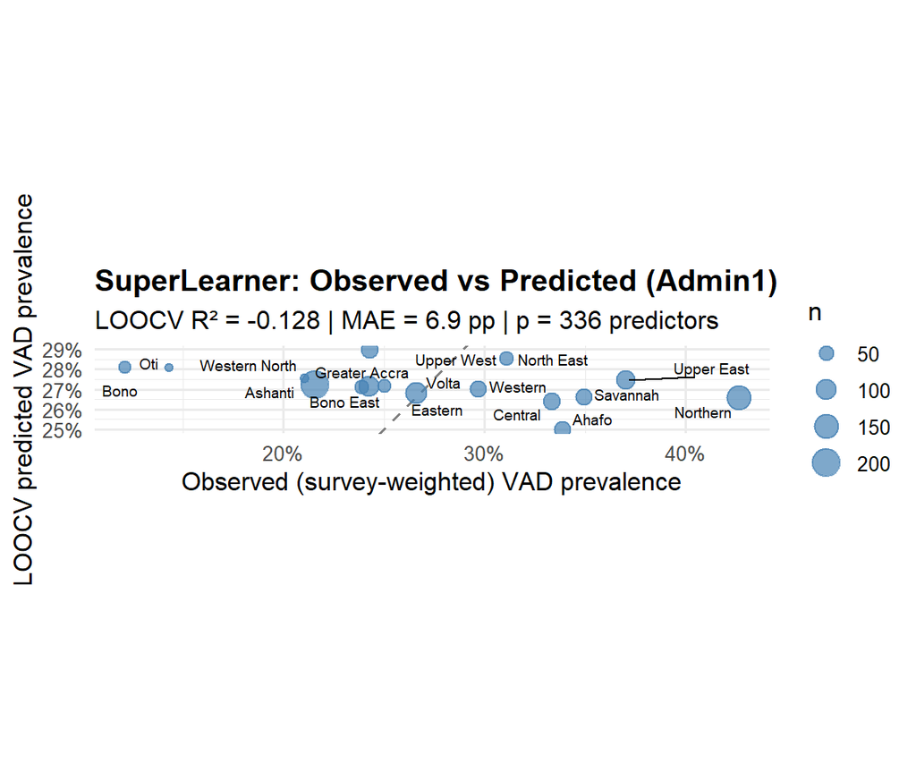

```r
sl_results <- data.frame(
  Admin1    = sl_data$Admin1,
  observed  = Y,
  predicted = cv_preds,
  n_children = sl_data$n_children
)

ggplot(sl_results, aes(x = observed, y = predicted)) +
  geom_abline(slope = 1, intercept = 0, linetype = "dashed", colour = "grey50") +
  geom_point(aes(size = n_children), colour = "steelblue", alpha = 0.7) +
  ggrepel::geom_text_repel(aes(label = Admin1), size = 2.5, max.overlaps = 20) +
  scale_x_continuous(labels = percent_format(1)) +
  scale_y_continuous(labels = percent_format(1)) +
  scale_size_area(name = "n", max_size = 6) +
  labs(x = "Observed (survey-weighted) VAD prevalence",
       y = "LOOCV predicted VAD prevalence",
       title = "SuperLearner: Observed vs Predicted (Admin1)",
       subtitle = sprintf("LOOCV R² = %.3f | MAE = %.1f pp | p = %d predictors",
                          r2_cv, mae_cv * 100, ncol(X))) +
  coord_fixed() +
  theme_minimal(base_size = 12) +
  theme(plot.title = element_text(face = "bold"))
```

### Individual Learner CV Risks

```r
risk_df <- data.frame(
  Learner  = sl_fit$libraryNames,
  CV_Risk  = round(sl_fit$cvRisk, 6),
  Weight   = round(coef(sl_fit), 4)
) %>%
  arrange(CV_Risk)

kable(risk_df, caption = "Individual learner CV risks (MSE) and ensemble weights")
```

Individual learner CV risks (MSE) and ensemble weights

|  | Learner | CV_Risk | Weight |
| --- | --- | --- | --- |
| SL.mean_All | SL.mean_All | 0.007081 | 0.7235 |
| SL.rf.small_All | SL.rf.small_All | 0.007438 | 0.2765 |
| SL.glmnet_All | SL.glmnet_All | 0.007637 | 0.0000 |

## Variable Importance

We assess variable importance using a **permutation-based** approach: for each predictor, we randomly shuffle its values across Admin1 units, re-predict using the fitted SuperLearner, and measure the increase in prediction error (MSE). A larger increase indicates higher importance. This is repeated 20 times per variable and averaged.

```r
set.seed(12345)

n_perm <- 20
baseline_mse <- mean((Y - predict(sl_fit, X)$pred[, 1])^2)

varimp_results <- lapply(names(X), function(var) {
  mse_perms <- replicate(n_perm, {
    X_perm <- X
    X_perm[[var]] <- sample(X_perm[[var]])
    pred_perm <- predict(sl_fit, X_perm)$pred[, 1]
    mean((Y - pred_perm)^2)
  })

  data.frame(
    Variable     = var,
    MSE_permuted = mean(mse_perms),
    stringsAsFactors = FALSE
  )
})

varimp_df <- do.call(rbind, varimp_results) %>%
  mutate(
    MSE_baseline = baseline_mse,
    Delta_MSE    = MSE_permuted - MSE_baseline,
    Pct_increase = Delta_MSE / MSE_baseline * 100
  ) %>%
  arrange(desc(Delta_MSE))

# Show top 20
varimp_df %>%
  head(20) %>%
  mutate(across(where(is.numeric), ~round(.x, 6))) %>%
  mutate(Pct_increase = sprintf("+%.1f%%", Pct_increase)) %>%
  kable(caption = "Top 20 most important GEE predictors (permutation importance)")
```

Top 20 most important GEE predictors (permutation importance)

| Variable | MSE_permuted | MSE_baseline | Delta_MSE | Pct_increase |
| --- | --- | --- | --- | --- |
| gee_fldas_2016_annual_mean__qg_tavg | 0.004420 | 0.004371 | 5.0e-05 | +1.1% |
| gee_soilzinc_ghana_2017__mean_0_20 | 0.004416 | 0.004371 | 4.5e-05 | +1.0% |
| gee_soilcec_ghana_2016__stdev_20_50 | 0.004415 | 0.004371 | 4.4e-05 | +1.0% |
| gee_soilsulfur_ghana_2017__stdev_0_20 | 0.004413 | 0.004371 | 4.2e-05 | +1.0% |
| gee_soilpotassium_ghana_2017__mean_0_20 | 0.004408 | 0.004371 | 3.8e-05 | +0.9% |
| gee_soilsulfur_ghana_2016__stdev_0_20 | 0.004407 | 0.004371 | 3.6e-05 | +0.8% |
| gee_fldas_2017_annual_mean__qg_tavg | 0.004405 | 0.004371 | 3.5e-05 | +0.8% |
| gee_wapor_ghana_2016__l1_npp_1621_l1_npp_d | 0.004403 | 0.004371 | 3.2e-05 | +0.7% |
| gee_soilcec_ghana_2017__stdev_20_50 | 0.004402 | 0.004371 | 3.2e-05 | +0.7% |
| gee_fldas_2017_annual_mean__soilmoi00_10cm_tavg | 0.004400 | 0.004371 | 2.9e-05 | +0.7% |
| gee_soiltotalcarbon_ghana_2017__stdev_0_20 | 0.004398 | 0.004371 | 2.7e-05 | +0.6% |
| gee_trmm_ghana_2011 | 0.004398 | 0.004371 | 2.7e-05 | +0.6% |
| gee_ndvi_ghana_2012 | 0.004397 | 0.004371 | 2.7e-05 | +0.6% |
| gee_ndvi_ghana_2014 | 0.004397 | 0.004371 | 2.6e-05 | +0.6% |
| gee_lst_night_2015_annual_mean__mean | 0.004397 | 0.004371 | 2.6e-05 | +0.6% |
| gee_soilzinc_ghana_2016__mean_0_20 | 0.004396 | 0.004371 | 2.5e-05 | +0.6% |
| gee_soilaluminium_ghana_2017__mean_0_20 | 0.004395 | 0.004371 | 2.4e-05 | +0.5% |
| gee_ndvi_ghana_2017 | 0.004395 | 0.004371 | 2.4e-05 | +0.5% |
| gee_soilpotassium_ghana_2016__mean_0_20 | 0.004394 | 0.004371 | 2.3e-05 | +0.5% |
| gee_ndvi_ghana_2020 | 0.004394 | 0.004371 | 2.3e-05 | +0.5% |

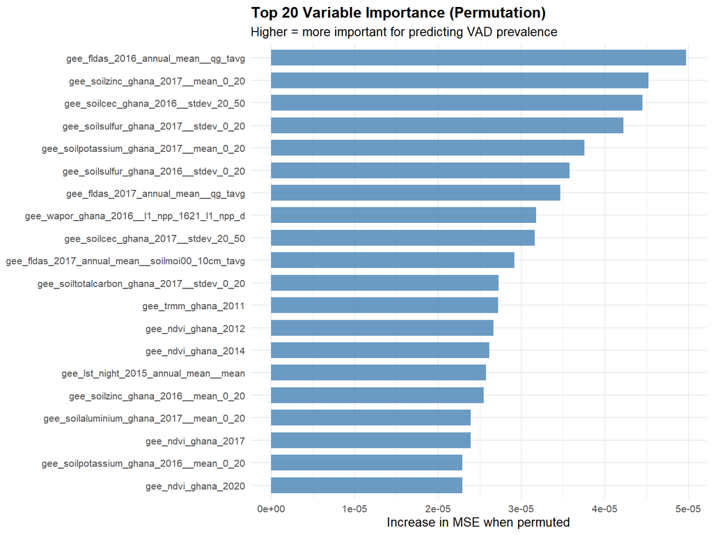

```r
top_n_imp <- min(20, sum(varimp_df$Delta_MSE > 0))
if (top_n_imp == 0) top_n_imp <- min(10, nrow(varimp_df))

varimp_top <- varimp_df %>%
  head(top_n_imp) %>%
  mutate(Variable = factor(Variable, levels = rev(Variable)))

ggplot(varimp_top, aes(x = Variable, y = Delta_MSE)) +
  geom_col(fill = "steelblue", alpha = 0.8, width = 0.7) +
  coord_flip() +
  labs(x = NULL,
       y = "Increase in MSE when permuted",
       title = sprintf("Top %d Variable Importance (Permutation)", top_n_imp),
       subtitle = "Higher = more important for predicting VAD prevalence") +
  theme_minimal(base_size = 10) +
  theme(plot.title = element_text(face = "bold"))
```

### Importance by Source Category

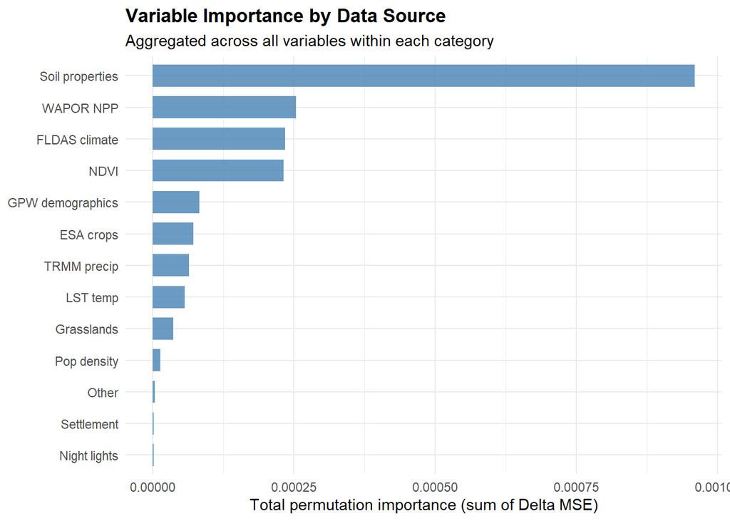

```r
varimp_cat <- varimp_df %>%
  mutate(
    source = case_when(
      grepl("ndvi", Variable)     ~ "NDVI",
      grepl("trmm", Variable)     ~ "TRMM precip",
      grepl("popdens", Variable)  ~ "Pop density",
      grepl("soil", Variable)     ~ "Soil properties",
      grepl("fldas", Variable)    ~ "FLDAS climate",
      grepl("wapor", Variable)    ~ "WAPOR NPP",
      grepl("lst", Variable)      ~ "LST temp",
      grepl("gpw_dem", Variable)  ~ "GPW demographics",
      grepl("gpw_grass", Variable) ~ "Grasslands",
      grepl("esa", Variable)      ~ "ESA crops",
      grepl("ghsl", Variable)     ~ "Settlement",
      grepl("ccnl", Variable)     ~ "Night lights",
      grepl("ghm|human_mod", Variable) ~ "Human mod",
      TRUE                        ~ "Other"
    )
  ) %>%
  group_by(source) %>%
  summarise(
    n_vars           = n(),
    total_importance = sum(pmax(Delta_MSE, 0)),
    max_importance   = max(Delta_MSE),
    .groups = "drop"
  ) %>%
  arrange(desc(total_importance))

varimp_cat %>%
  mutate(source = factor(source, levels = rev(source))) %>%
  ggplot(aes(x = source, y = total_importance)) +
  geom_col(fill = "steelblue", alpha = 0.8, width = 0.7) +
  coord_flip() +
  labs(x = NULL,
       y = "Total permutation importance (sum of Delta MSE)",
       title = "Variable Importance by Data Source",
       subtitle = "Aggregated across all variables within each category") +
  theme_minimal(base_size = 11) +
  theme(plot.title = element_text(face = "bold"))
```

```r
varimp_cat %>%
  mutate(across(where(is.numeric) & !matches("n_vars"), ~round(.x, 6))) %>%
  kable(caption = "Importance by source category")
```

Importance by source category

| source | n_vars | total_importance | max_importance |
| --- | --- | --- | --- |
| Soil properties | 104 | 0.000959 | 4.5e-05 |
| WAPOR NPP | 72 | 0.000254 | 3.2e-05 |
| FLDAS climate | 32 | 0.000234 | 5.0e-05 |
| NDVI | 12 | 0.000232 | 2.7e-05 |
| GPW demographics | 77 | 0.000082 | 8.0e-06 |
| ESA crops | 6 | 0.000072 | 1.9e-05 |
| TRMM precip | 10 | 0.000065 | 2.7e-05 |
| LST temp | 4 | 0.000056 | 2.6e-05 |
| Grasslands | 2 | 0.000036 | 2.1e-05 |
| Pop density | 14 | 0.000014 | 3.0e-06 |
| Other | 1 | 0.000004 | 4.0e-06 |
| Settlement | 1 | 0.000002 | 2.0e-06 |
| Night lights | 1 | 0.000001 | 1.0e-06 |

## Next Steps

This Admin1/Admin2-level dataset with 345 GEE predictors is ready for machine learning prediction models:

1. **Add other countries** — repeat this pipeline for Gambia, Malawi, and Sierra Leone to build a multi-country training set.
2. **Feature selection** — use the variable importance results to select the most predictive subset of GEE covariates.
3. **Fit richer ML models** — with more observations (multi-country), use the full SuperLearner stack (elastic net, random forest, GAM, XGBoost) and spatial block CV.
4. **Spatial validation** — leave-one-region-out CV to assess out-of-sample prediction accuracy across regions.
5. **Wall-to-wall prediction** — predict VAD prevalence for all GADM Admin2 polygons (including those without survey data) using the fitted model.